# MplusAutomation Example

First, load the packages in R.

```r
library(MplusAutomation)
library(MASS)
```

Next, setup some block diagonal correlation matrix and simulate a dataset of 50,000 observations, our “population” that we will sample from. I set the seed so it is reproducible.

```r
# simulate some data
cor1 <- matrix(.6, 3, 3)
diag(cor1) <- 1
cor2 <- matrix(.3, 3, 3)

# block diagonal cor structur
cor <- rbind(
  cbind(cor1, cor2, cor2),
  cbind(cor2, cor1, cor2),
  cbind(cor2, cor2, cor1))

set.seed(1234)
dat <- as.data.frame(mvrnorm(n = 50000, mu = rep(0, 9),
        Sigma = cor))
```

Next, setup the model for Mplus. All that is *needed* is the MODEL, SAVEDATA and rdata. The rest of the Mplus input file is built automatically, but I wanted to show TITLE and ANALYSIS sections, and there are additional sections for most the headings in Mplus you can use as needed.

```r
m <- mplusObject(
    TITLE = "Example Factor Model",
    ANALYSIS = "
      ESTIMATOR = ML;
      PROCESSORS = 2;
    ",
    MODEL = "
    f1 BY V1 V2 V3;
    f2 BY V4 V5 V6;
    f3 BY V7 V8 V9;
    g BY f1 f2 f3;
    ",
    SAVEDATA = "
      file is scores.txt;
      save = fscores;
    ",
    rdata = dat)
```

Now we can run the model. The results are written out, run, and automatically read back into R and saved in the “m.fit” object automatically.

```r
m.fit <- mplusModeler(m, dataout = "run_all.dat", run = 1)
```

Running model: run_all.inp System command: C:32.exe /c cd “c:Wiley” && “Mplus” “run_all.inp” Reading model: run_all.out

If you are using the latest development version of MplusAutomation from github (see https://github.com/michaelhallquist/MplusAutomation which also tells you how to install the development version if you don’t have it), then this works. SummaryTable is a new function that “knows” about the newer mplusObject and mplusModeler object outputs. It also lets you pick the format you want the summary table shown in (screen/console, popup, markdown, HTML, LaTeX).

```r
SummaryTable(m.fit, keepCols =
  c("Title", "Parameters", "CFI", "SRMR", "RMSEA_Estimate", "AIC", "BIC"))
```

```
              Title Parameters CFI  SRMR RMSEA_Estimate     AIC
```

Otherwise, you can use this which will bring up a popup box with the results

```r
# showSummaryTable(m.fit, keepCols =
#  c("Title", "Parameters", "CFI", "SRMR", "RMSEA_Estimate", "AIC", "BIC"))
```

Here are all the data and factor scores MplusAutomation reads in from Mplus (parameters etc. are elsewhere).

Continued

| V1 | V2 | V3 | V4 | V5 | V6 | V7 | V8 | V9 |
| --- | --- | --- | --- | --- | --- | --- | --- | --- |
| -0.329 | 0.707 | -0.508 | -0.735 | -0.969 | -1.167 | -1.179 | -1.412 | -1.65 |
| -0.568 | -0.238 | 0.849 | -0.126 | 0.65 | 0.321 | 0.143 | 0.343 | 0.29 |
| 0.35 | 0.678 | -0.034 | 2.08 | 1.152 | 1.338 | 0.455 | -0.094 | 0.581 |
| -1.146 | -0.292 | -0.19 | -2.313 | -2.922 | -1.315 | -2.65 | -2.021 | -1.224 |
| 0.924 | 1.365 | 0.415 | -1.085 | -0.425 | 0.814 | 0.466 | 0.427 | -0.326 |
| 0.166 | -0.883 | 0.799 | 1.436 | 0.449 | -0.423 | 0.755 | 0.052 | 0.685 |

Continued from above

| F1 | F1_SE | F2 | F2_SE | F3 | F3_SE | G | G_SE |
| --- | --- | --- | --- | --- | --- | --- | --- |
| -0.202 | 0.318 | -0.832 | 0.32 | -1.149 | 0.32 | -0.541 | 0.311 |
| 0.053 | 0.318 | 0.229 | 0.32 | 0.217 | 0.32 | 0.124 | 0.311 |
| 0.38 | 0.318 | 1.202 | 0.32 | 0.37 | 0.32 | 0.49 | 0.311 |
| -0.702 | 0.318 | -1.837 | 0.32 | -1.693 | 0.32 | -1.055 | 0.311 |
| 0.674 | 0.318 | -0.102 | 0.32 | 0.191 | 0.32 | 0.194 | 0.311 |
| 0.093 | 0.318 | 0.406 | 0.32 | 0.417 | 0.32 | 0.228 | 0.311 |

Now we can do things in R with the output, like make a histogram of the second-order factor scores.

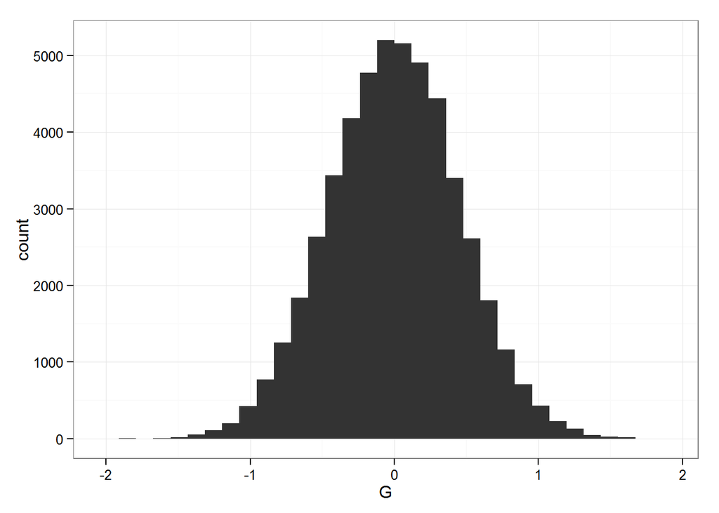

```r
library(ggplot2)
ggplot(m.fit$results$savedata, aes(G)) +
  geom_histogram() +
  theme_bw()
```

That just shows how things work generally. It is very easy in R to do this a whole bunch of times on samples from the data (or different datasets, or…). For an eample, I am just doing 9 runs, but you can make it 500 or whatever. Say you want to try taking samples of 100, 250, and 500 people. To keep things organized, I made a “conditions” data frame.

```r
conditions <- expand.grid(seeds = c(403L, 192L, 861524647L),
                          Nsize = c(100, 250, 500))
```

| seeds | Nsize |
| --- | --- |
| 403 | 100 |
| 192 | 100 |
| 861524647 | 100 |
| 403 | 250 |
| 192 | 250 |
| 861524647 | 250 |
| 403 | 500 |
| 192 | 500 |
| 861524647 | 500 |

Now, loop through the conditions and run it.

```r
big.res <- lapply(1:nrow(conditions), function(i) {
  # set seed so reproducible
  set.seed(conditions$seeds[i])
  # sample from the data
  sampdata <- dat[sample(1:nrow(dat), size = conditions$Nsize[i]), ]
  # use the update() function to update the previous model, using a new dataset
  # and then run it (results read and stored automatically)
  mplusModeler(update(m, rdata = sampdata),
               dataout = paste0("run_sample_", i, ".dat"),
               run = 1)
})
```

Running model: run_sample_1.inp System command: C:32.exe /c cd “c:Wiley” && “Mplus” “run_sample_1.inp” Reading model: run_sample_1.out

Running model: run_sample_2.inp System command: C:32.exe /c cd “c:Wiley” && “Mplus” “run_sample_2.inp” Reading model: run_sample_2.out

Running model: run_sample_3.inp System command: C:32.exe /c cd “c:Wiley” && “Mplus” “run_sample_3.inp” Reading model: run_sample_3.out

Running model: run_sample_4.inp System command: C:32.exe /c cd “c:Wiley” && “Mplus” “run_sample_4.inp” Reading model: run_sample_4.out

Running model: run_sample_5.inp System command: C:32.exe /c cd “c:Wiley” && “Mplus” “run_sample_5.inp” Reading model: run_sample_5.out

Running model: run_sample_6.inp System command: C:32.exe /c cd “c:Wiley” && “Mplus” “run_sample_6.inp” Reading model: run_sample_6.out

Running model: run_sample_7.inp System command: C:32.exe /c cd “c:Wiley” && “Mplus” “run_sample_7.inp” Reading model: run_sample_7.out

Running model: run_sample_8.inp System command: C:32.exe /c cd “c:Wiley” && “Mplus” “run_sample_8.inp” Reading model: run_sample_8.out

Running model: run_sample_9.inp System command: C:32.exe /c cd “c:Wiley” && “Mplus” “run_sample_9.inp” Reading model: run_sample_9.out

Again in latest development version on github, this will just work and give you summaries. I chhoose markdown output, as I am writing this document in R markdown.

```r
SummaryTable(big.res, type = "markdown", keepCols =
  c("Title", "Parameters", "CFI", "SRMR", "RMSEA_Estimate", "AIC", "BIC"),
  split.tables = 200)
```

[output not shown]

We can also compare factor score distributions. First we’ll pull out just the factor scores into a “long” dataset.

```r
fscores.long <- do.call(rbind, lapply(1:nrow(conditions), function(i) {
  cbind(Condition = i,
        Nsize = conditions$Nsize[i],
        # suppose all you care about are factor scores and SEs for the G factor
        # but modify as needed or even keep all
        big.res[[i]]$results$savedata[, c("F1", "F2", "F3", "G", "G_SE")])
}))
```

which looks like

| Condition | Nsize | F1 | F2 | F3 | G | G_SE |
| --- | --- | --- | --- | --- | --- | --- |
| 1 | 100 | -0.081 | -0.22 | 0.418 | -0.019 | 0.34 |
| 1 | 100 | -0.77 | -0.014 | 0.121 | -0.239 | 0.34 |
| 1 | 100 | -0.519 | -0.821 | -1.022 | -0.541 | 0.34 |
| 1 | 100 | 0.698 | 0.729 | 0.192 | 0.448 | 0.34 |
| 1 | 100 | -1.121 | -0.494 | -1.135 | -0.673 | 0.34 |
| 1 | 100 | -0.129 | 0.315 | -1.415 | -0.181 | 0.34 |

and we can plot it now.

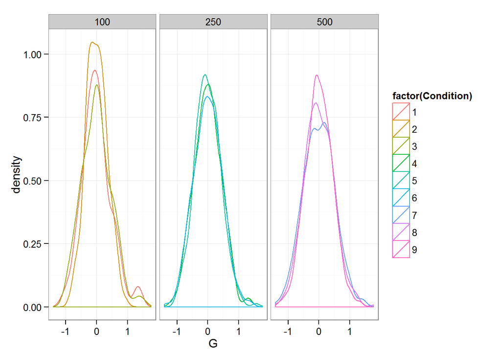

```r
ggplot(fscores.long, aes(G, colour = factor(Condition))) +
  geom_density() +
  facet_wrap(~ Nsize) +
  theme_bw()
```

Or perhaps look at correlations of each factor with G.

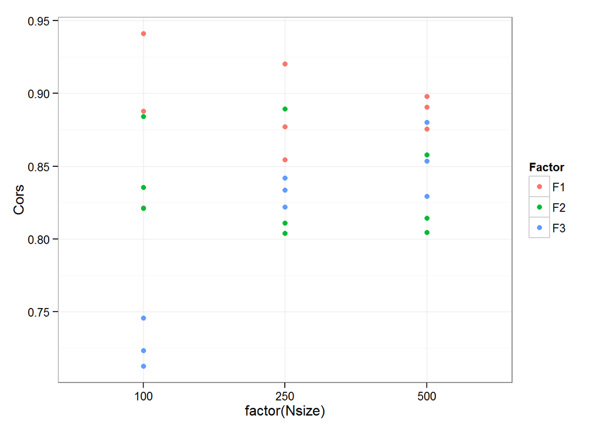

```r
cors <- do.call(rbind, by(fscores.long, fscores.long$Condition, function(d) {
  r <- cor(d[, c("F1", "F2", "F3", "G")])[1:3, 4]
  data.frame(Factor = names(r), Cors = as.vector(r),
             Condition = unique(d$Condition),
             Nsize = unique(d$Nsize))
}))

ggplot(cors, aes(factor(Nsize), Cors, colour = Factor)) +
  geom_point() +
  theme_bw()
```

So that’s all there is to it!. You can easily vary things, and run the same model on different datasets, or use R to build a variety of models and run them on different datasets, simulate, etc. as needed.